# CCA Example

## Data: ADT meta-analysis

Here, we read in the data:

```r
library(tidyverse)

adt <- readRDS("../data/adt_data.RDS")
```

A useful way to subset the data is to retain only one effect size per contrast. Here, we choose the *last* contrast reported as measured by the timing post-intervention.

```r
# Subset to get last follow up time for each contrast
adt_example <- adt %>%
  group_by(studyid, groupid1, groupid2) %>%
  arrange(desc(estimingpost)) %>%
  slice(1) %>%
  ungroup()
```

To simplify things, we generate a few categorical variables:

- `g1out`: whether treatments were outpatient
- `multidrug`: whether patients presented using multiple drugs
- `long`: if the treatment was longer than 100 days
- `gXhi`: if group X had high intensity treatment (>1.5 hrs per week). **NOTE: I’d recommend using these for our example**.

```r
# Mutate to get easier names
dd <- adt_example %>%
  mutate(g1out = (g1loc == "2. Outpatient"),
         multidrug = (dvmicro == "7. Mixed drugs"),
         long = (g2txdays > 100)) %>%
  select(studyid, es_g, se_g,
         g1hrs = g1hrsperweek, g2hrs = g2hrsperweek,
         g1out, multidrug, long) %>%
  mutate(v_g = se_g^2,
         g1hi = (g1hrs > 1.5),
         g2hi = (g2hrs > 1.5))
```

# Models for example

It would seem that we should demonstrate both a complete- and available-case analysis. Consider the subset of the ADT data that contains 74 effect estimates from 46 studies. These effect estimates involve contrasts between groups in a study that are subjected to different treatment conditions, denoted in the data as *Group 1* and *Group 2*. Treatment conditions vary across studies, and include assertive continuing care (ACC), behavioral therapy, (CBT), motivational enhancement therapy (MET), and family therapy, as well as “practice as usual” control groups where subjects were referred to community services, but did not receive specific substance abuse treatment.

The researchers who collected these data extracted several covariates regarding the treatment type, intensity (in hours per week), and duration (in days), as well as information regarding the racial composition of each group in a contrast. To demonstrate a complete- and available-case analysis, consider two covariates regarding whether each group received a high-intensity intervention (>1.5 hours per week). Let $X_{i1} = 1$ if group 1 received a high-intensity intervention and $X_{i1} = 0$ if group 1 received a low-intensity intervention. Similarly, let $X_{i2} = 1$ if group 2 received a high intensity and $X_{i2} = 0$ if group 2 received a low-intensity intervention.

In the data, the treatment intensity is missing for some of the effects. The table below shows that only 37 of the 74 have a reported treatment intensity for both groups.

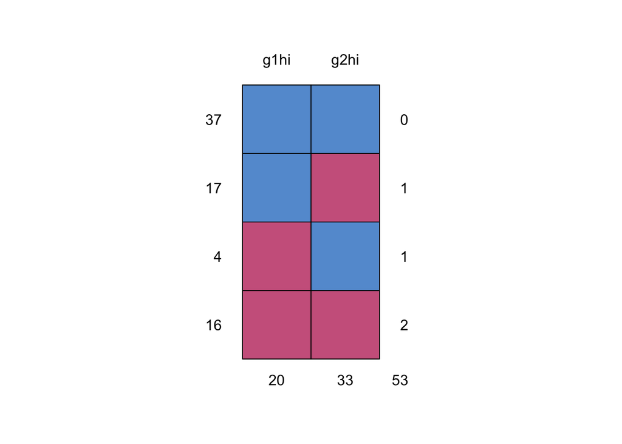

| g1_intensity | g2_intensity | counts | percent |
| --- | --- | --- | --- |
| Observed | Observed | 37 | 0.50 |
| Observed | Missing | 17 | 0.23 |
| Missing | Observed | 4 | 0.05 |
| Missing | Missing | 16 | 0.22 |

For reference, the correlation between $X_{i1}$ and $X_{i2}$ among the effects where both are observed is 0.5202089

A complete case analysis would include only the 37 effects for which both covariates are observed. Because studies produce multiple effect sizes, we use robust variance estimation to compute standard errors:

```r
# RVE
library(robumeta)

rv_mod_hiint <- robu(formula = es_g ~ g1hi + g2hi,
                     data = dd,
                     studynum = studyid,
                     var.eff.size = v_g,
                     # rho = 0.5,
                     small = TRUE)
rv_mod_hiint
```

```
## RVE: Correlated Effects Model with Small-Sample Corrections
##
## Model: es_g ~ g1hi + g2hi
##
## Number of studies = 28
## Number of outcomes = 37 (min = 1 , mean = 1.32 , median = 1 , max = 6 )
## Rho = 0.8
## I.sq = 61.36786
## Tau.sq = 0.08260043
##
##                Estimate StdErr t-value   dfs P(|t|>) 95% CI.L 95% CI.U Sig
## 1 X.Intercept.    0.108 0.0634   1.700 17.01  0.1074  -0.0260    0.241
## 2     g1hiTRUE    0.443 0.1569   2.823  3.53  0.0551  -0.0167    0.903   *
## 3     g2hiTRUE   -0.208 0.2581  -0.806  4.92  0.4577  -0.8747    0.459
## ---
## Signif. codes: < .01 *** < .05 ** < .10 *
## ---
## Note: If df < 4, do not trust the results
```

Note that by default, most programs that run meta-regressions will only use complete cases.

However, in the table above, we see that there are an additional 17 effects for which $X_{i1}$ is observed, but not $X_{i2}$. Thus, one may be tempted to include those observations, but exclude $X_{i2}$ from the model. This is referred to as a shifting-case analysis or a shifting units of analysis.

```r
rv_mod_hiint_g1 <- robu(formula = es_g ~ g1hi,
                        data = dd,
                        studynum = studyid,
                        var.eff.size = v_g,
                        small = TRUE)

rv_mod_hiint_g1
```

```
## RVE: Correlated Effects Model with Small-Sample Corrections
##
## Model: es_g ~ g1hi
##
## Number of studies = 38
## Number of outcomes = 54 (min = 1 , mean = 1.42 , median = 1 , max = 6 )
## Rho = 0.8
## I.sq = 59.48863
## Tau.sq = 0.06955662
##
##                Estimate StdErr t-value  dfs P(|t|>) 95% CI.L 95% CI.U Sig
## 1 X.Intercept.    0.144 0.0551    2.61 21.3  0.0164   0.0291    0.258  **
## 2     g1hiTRUE    0.273 0.1456    1.87 21.5  0.0748  -0.0297    0.575   *
## ---
## Signif. codes: < .01 *** < .05 ** < .10 *
## ---
## Note: If df < 4, do not trust the results
```

Note that this estimate is much smaller, by over one third, than the complete-case analysis above.

A similar model can be fit for $X_{i2}$, which yields a point estimate that is quite different (and even in a different direction) than the estimate in the complete-case model:

```r
rv_mod_hiint_g2 <- robu(formula = es_g ~ g2hi,
                        data = dd,
                        studynum = studyid,
                        var.eff.size = v_g,
                        small = TRUE)

rv_mod_hiint_g2
```

```
## RVE: Correlated Effects Model with Small-Sample Corrections
##
## Model: es_g ~ g2hi
##
## Number of studies = 28
## Number of outcomes = 41 (min = 1 , mean = 1.46 , median = 1 , max = 6 )
## Rho = 0.8
## I.sq = 63.16496
## Tau.sq = 0.08994234
##
##                Estimate StdErr t-value   dfs P(|t|>) 95% CI.L 95% CI.U Sig
## 1 X.Intercept.    0.154 0.0637   2.415 19.20  0.0258   0.0206    0.287  **
## 2     g2hiTRUE    0.163 0.2563   0.636  7.67  0.5432  -0.4325    0.759
## ---
## Signif. codes: < .01 *** < .05 ** < .10 *
## ---
## Note: If df < 4, do not trust the results
```

## Correction for missingness

```r
summary(ebp$bias_b0CC)
```

```
##    Min. 1st Qu.  Median    Mean 3rd Qu.    Max.
## 0.04258 0.05844 0.06277 0.06242 0.06708 0.07508
```

```r
summary(ebp$bias_b1CC)
```

```
##      Min.   1st Qu.    Median      Mean   3rd Qu.      Max.
## -0.002481  0.043088  0.064908  0.060882  0.077368  0.119638
```

```r
summary(ebp$omv_bias_b0)
```

```
##       Min.    1st Qu.     Median       Mean    3rd Qu.       Max.
## -0.0482200 -0.0134665 -0.0074559 -0.0074799 -0.0009344  0.0240314
```

```r
summary(ebp$omv_bias_b1)
```

```
##      Min.   1st Qu.    Median      Mean   3rd Qu.      Max.
## -0.311726 -0.089223 -0.041532 -0.050899 -0.005088  0.107140
```

# Other models fit

Potential models fit with RVE:

```r
# Mod 1a: Were interventions outpatient (mostly study-level)
rv_mod_outpatient <- robu(formula = es_g ~ g1out,
                          data = dd,
                          studynum = studyid,
                          var.eff.size = v_g,
                          small = TRUE)

# Mod 1b: Were interventions long (>100 days) (mostly study-level)
rv_mod_long <- robu(formula = es_g ~ long,
                    data = dd,
                    studynum = studyid,
                    var.eff.size = v_g,
                    small = TRUE)

# Mod 2a: Hours per week for both groups (complete cases)
rv_mod_hrs <-  robu(formula = es_g ~ g1hrs + g2hrs,
                    data = dd,
                    studynum = studyid,
                    var.eff.size = v_g,
                    # rho = 0.5,
                    small = TRUE)

# Mod 2b: Hi-intensity for each group (>1.5 hrs per week) complete cases
rv_mod_hiint <- robu(formula = es_g ~ g1hi + g2hi,
                     data = dd,
                     studynum = studyid,
                     var.eff.size = v_g,
                     # rho = 0.5,
                     small = TRUE)

# Mod 2c: Hi-intensity for only group 1 (>1.5 hrs per week) shifting cases
rvmod_hiint_g1 <- robu(formula = es_g ~ g1hi,
                       data = dd,
                       studynum = studyid,
                       var.eff.size = v_g,
                       # rho = 0.5,
                       small = TRUE)

rvmod_hiint_g2 <- robu(formula = es_g ~ g2hi,
                       data = dd %>% mutate(g1hi = g1hrs > 1.5,
                                            g2hi = g2hrs > 1.5),
                       studynum = studyid,
                       var.eff.size = v_g,
                       # rho = 0.5,
                       small = TRUE)
```

Potential parameters of interest

```r
mis_mech_df <- dd %>%
  mutate(long_na = is.na(long),
         multidrug_na = is.na(multidrug),
         g1out_na = is.na(g1out),
         g1hrs_na = is.na(g1hrs),
         g2hrs_na = is.na(g2hrs))

glm(g1out_na ~ es_g + v_g,
    data = mis_mech_df,
    family = "binomial")
```

```
##
## Call:  glm(formula = g1out_na ~ es_g + v_g, family = "binomial", data = mis_mech_df)
##
## Coefficients:
## (Intercept)         es_g          v_g
##  -2.657e+01   -2.483e-14    2.684e-15
##
## Degrees of Freedom: 73 Total (i.e. Null);  71 Residual
## Null Deviance:       0
## Residual Deviance: 4.293e-10     AIC: 6
```

```r
glm(multidrug_na ~ es_g + v_g,
    data = mis_mech_df,
    family = "binomial")
```

```
##
## Call:  glm(formula = multidrug_na ~ es_g + v_g, family = "binomial",
##     data = mis_mech_df)
##
## Coefficients:
## (Intercept)         es_g          v_g
##  -2.657e+01   -2.483e-14    2.684e-15
##
## Degrees of Freedom: 73 Total (i.e. Null);  71 Residual
## Null Deviance:       0
## Residual Deviance: 4.293e-10     AIC: 6
```

```r
glm(long_na ~ es_g + v_g,
    data = mis_mech_df,
    family = "binomial")
```

```
##
## Call:  glm(formula = long_na ~ es_g + v_g, family = "binomial", data = mis_mech_df)
##
## Coefficients:
## (Intercept)         es_g          v_g
##     -0.6187       1.9932      -7.6757
##
## Degrees of Freedom: 73 Total (i.e. Null);  71 Residual
## Null Deviance:       93.25
## Residual Deviance: 86.95     AIC: 92.95
```

```r
glm(g1hrs_na ~ es_g + v_g,
    data = mis_mech_df,
    family = "binomial")
```

```
##
## Call:  glm(formula = g1hrs_na ~ es_g + v_g, family = "binomial", data = mis_mech_df)
##
## Coefficients:
## (Intercept)         es_g          v_g
##       1.639       -2.078      -50.718
##
## Degrees of Freedom: 73 Total (i.e. Null);  71 Residual
## Null Deviance:       86.36
## Residual Deviance: 62.11     AIC: 68.11
```

```r
glm(g2hrs_na ~ es_g + v_g,
    data = mis_mech_df,
    family = "binomial")
```

```
##
## Call:  glm(formula = g2hrs_na ~ es_g + v_g, family = "binomial", data = mis_mech_df)
##
## Coefficients:
## (Intercept)         es_g          v_g
##      0.1327       0.7888      -7.0883
##
## Degrees of Freedom: 73 Total (i.e. Null);  71 Residual
## Null Deviance:       101.7
## Residual Deviance: 99.02     AIC: 105
```

```r
cor(dd$g1hrs, dd$g2hrs, use = "pairwise.complete")
```

```
## [1] 0.9243856
```

```r
cor(dd$g1hi, dd$g2hi, use = "pairwise.complete")
```

```
## [1] 0.5202089
```